# Analysis for spoana LT

y.hira

2019/03/10

# Introduction

- キャリア全体のkeep/break率の分析(Reger Federer 100 title記念)

# Preparation

- ライブラリやデータの読み込み等

## Load Libraries

```r
library(tidyverse)
library(DT)
library(viridis) # color pallet
library(ggExtra)
library(gghighlight) #highlight
library(ggridges) #joy plot
```

## Read Data

```r
df <- readr::read_csv("tennis_career.csv")
```

## Set Options

```r
#ggplotの文字化け対策
theme_set(theme_bw(base_family = "HiraKakuProN-W3"))
```

# Data Check

- 今回のデータセットの確認

## glimpse()

- player: 選手名
- percentage_service: サービスゲームの獲得率(keep率)
- percentage_return: リターンゲームの獲得率(break率)
- games_won_service: 獲得したサービスゲーム数
- matches: 試合数
- surface: コートの種類(Allは全コート分)
- games_total_service: 全サービスゲーム数
- games_won_return: 獲得したリターンゲーム数
- games_total_return: 全リターンゲーム数

```r
df %>% dplyr::glimpse()
```

```
## Observations: 440
## Variables: 9
## $ player              <chr> "Roger Federer", "Pete Sampras", "Richard K…
## $ percentage_service  <dbl> 88.77, 88.75, 87.23, 85.82, 85.66, 85.60, 8…
## $ games_won_service   <dbl> 15851, 9266, 6770, 4697, 10508, 11060, 4575…
## $ games_total_service <dbl> 17856, 10441, 7761, 5473, 12267, 12921, 536…
## $ matches             <dbl> 1391, 792, 606, 418, 983, 1091, 417, 583, 5…
## $ surface             <chr> "All", "All", "All", "All", "All", "All", "…
## $ percentage_return   <dbl> 26.70, 24.05, 21.17, 23.63, 32.12, 33.43, 2…
## $ games_won_return    <dbl> 4662, 2460, 1634, 1293, 3832, 4291, 1253, 1…
## $ games_total_return  <dbl> 17461, 10227, 7717, 5471, 11932, 12837, 532…
```

## summary()

```r
df %>% summary()
```

```
##     player          percentage_service games_won_service
##  Length:440         Min.   :71.52      Min.   :  164.0
##  Class :character   1st Qu.:76.75      1st Qu.:  970.2
##  Mode  :character   Median :79.73      Median : 2154.5
##                     Mean   :79.93      Mean   : 2803.8
##                     3rd Qu.:82.80      3rd Qu.: 3974.2
##                     Max.   :92.76      Max.   :15851.0
##  games_total_service    matches          surface
##  Min.   :  198       Min.   :  15.00   Length:440
##  1st Qu.: 1208       1st Qu.:  87.75   Class :character
##  Median : 2764       Median : 233.50   Mode  :character
##  Mean   : 3516       Mean   : 285.47
##  3rd Qu.: 5080       3rd Qu.: 420.25
##  Max.   :17856       Max.   :1391.00
##  percentage_return games_won_return games_total_return
##  Min.   :16.74     Min.   :  40.0   Min.   :  198
##  1st Qu.:21.91     1st Qu.: 263.8   1st Qu.: 1206
##  Median :24.66     Median : 745.5   Median : 2767
##  Mean   :24.97     Mean   : 907.9   Mean   : 3503
##  3rd Qu.:27.48     3rd Qu.:1293.5   3rd Qu.: 5067
##  Max.   :42.94     Max.   :4662.0   Max.   :17461
```

## sample data

- surface == “All”のデータ

```r
df %>%
  dplyr::filter(surface == "All") %>%
  dplyr::arrange(desc(matches)) %>%
  DT::datatable()
```

|  | player | percentage_service | games_won_service | games_total_service | matches | surface | percentage_return | games_won_return | games_total_return |
| --- | --- | --- | --- | --- | --- | --- | --- | --- | --- |
| 1 | Roger Federer | 88.77 | 15851 | 17856 | 1391 | All | 26.7 | 4662 | 17461 |
| 2 | Rafael Nadal | 85.6 | 11060 | 12921 | 1091 | All | 33.43 | 4291 | 12837 |
| 3 | David Ferrer | 77.56 | 9933 | 12807 | 1069 | All | 31.43 | 3983 | 12671 |
| 4 | Novak Djokovic | 85.66 | 10508 | 12267 | 983 | All | 32.12 | 3832 | 11932 |
| 5 | Tomas Berdych | 84.46 | 9646 | 11421 | 928 | All | 24.05 | 2702 | 11237 |
| 6 | Fernando Verdasco | 80.55 | 9218 | 11444 | 909 | All | 24.08 | 2763 | 11473 |
| 7 | Mikhail Youzhny | 77.37 | 8395 | 10851 | 882 | All | 25.32 | 2741 | 10825 |
| 8 | Tommy Robredo | 78.41 | 8338 | 10634 | 871 | All | 25.49 | 2729 | 10706 |
| 9 | Tommy Haas | 81.63 | 8841 | 10830 | 867 | All | 23.45 | 2495 | 10638 |
| 10 | Carlos Moya | 79.76 | 8495 | 10651 | 856 | All | 25.32 | 2704 | 10679 |

[output cut: 120 more lines]

# Visualize

- 色々な角度からデータを眺めてみる

## keep/break率の分布(surface == “All”)

keep/break率のどちらも200位にランクインしている選手で散布図を作成  
(正直、この図に名前が入っているだけですごい選手…)

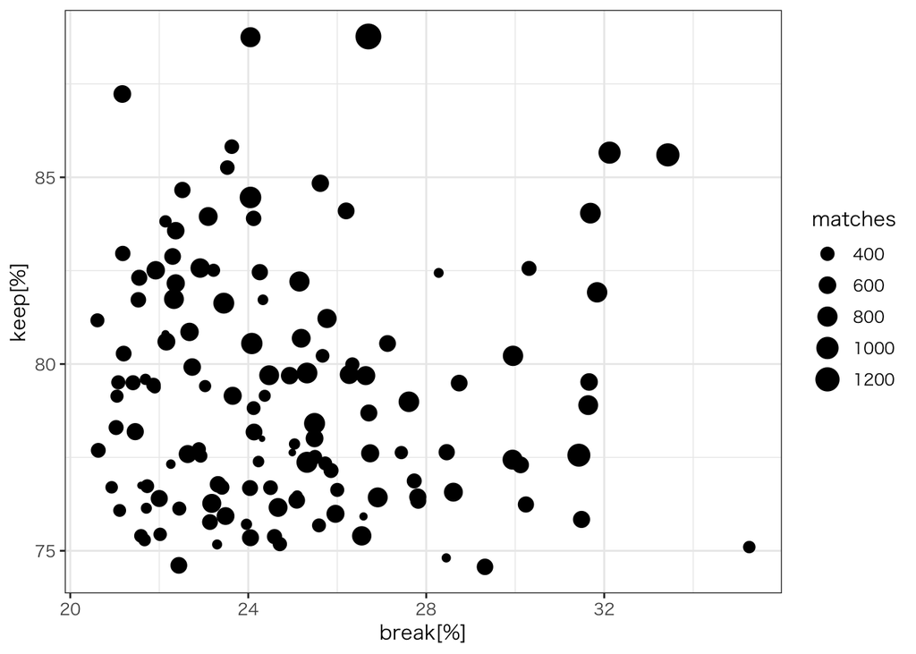

```r
df %>%
  dplyr::filter(surface == "All") %>%
  na.omit() %>%
  ggplot(aes(x=percentage_return, y=percentage_service, size=matches)) +
  geom_point() +
  xlab("break[%]") +
  ylab("keep[%]")
```

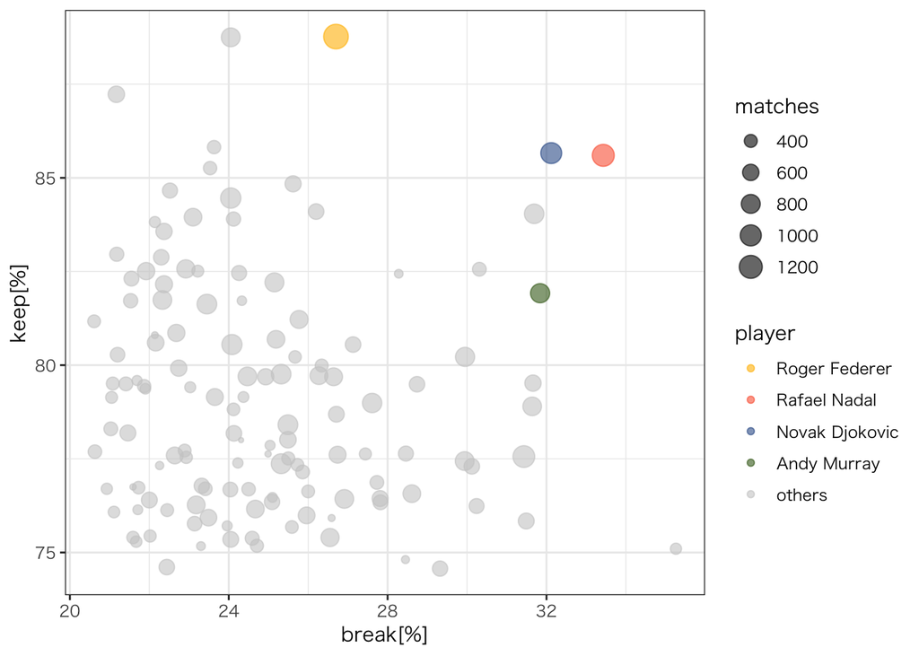

```r
player_list <- c("Roger Federer", "Rafael Nadal", "Novak Djokovic", "Andy Murray" , "others")
color_list <- c("Roger Federer" = "#ffbb00", "Rafael Nadal" = "#fb6542", "Novak Djokovic" = "#375e97", "Andy Murray" = "#3f671c", "others" = "gray80")

df %>%
  dplyr::filter(surface == "All") %>%
  na.omit() %>%
  dplyr::mutate(player =  ifelse(player %in% player_list, player, "others")) %>%
  transform(player = factor(player, levels = player_list)) %>%
  ggplot(aes(x=percentage_return, y=percentage_service, color=player, size=matches)) +
  geom_point(alpha = 0.6) +
  scale_color_manual(values = color_list) +
  #scale_color_viridis() +
  xlab("break[%]") +
  ylab("keep[%]")
```

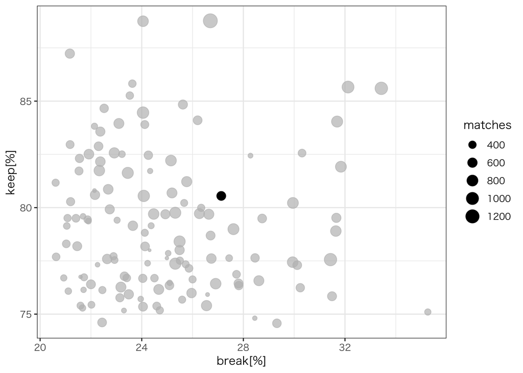

```r
df %>%
  dplyr::filter(surface == "All") %>%
  na.omit() %>%
  ggplot(aes(x=percentage_return, y=percentage_service, size=matches)) +
  geom_point() +
  scale_color_viridis() +
  gghighlight(player == "Kei Nishikori") +
  xlab("break[%]") +
  ylab("keep[%]")
```

## keep/break率の分布(surface == “Clay”)

keep/break率のどちらも200位にランクインしている選手で散布図を作成  
(正直、この図に名前が入っているだけですごい選手…)

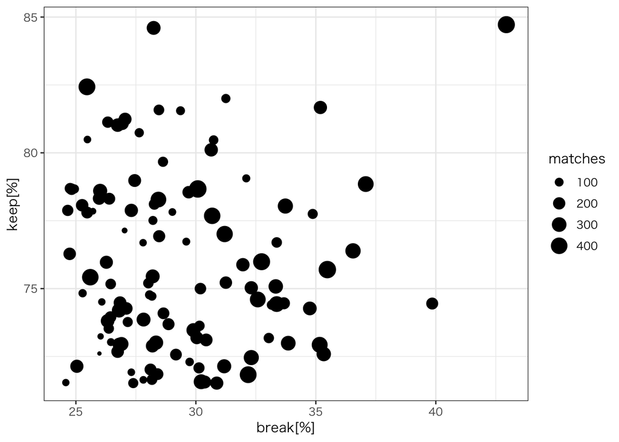

```r
df %>%
  dplyr::filter(surface == "Clay") %>%
  na.omit() %>%
  ggplot(aes(x=percentage_return, y=percentage_service, size=matches)) +
  geom_point() +
  xlab("break[%]") +
  ylab("keep[%]")
```

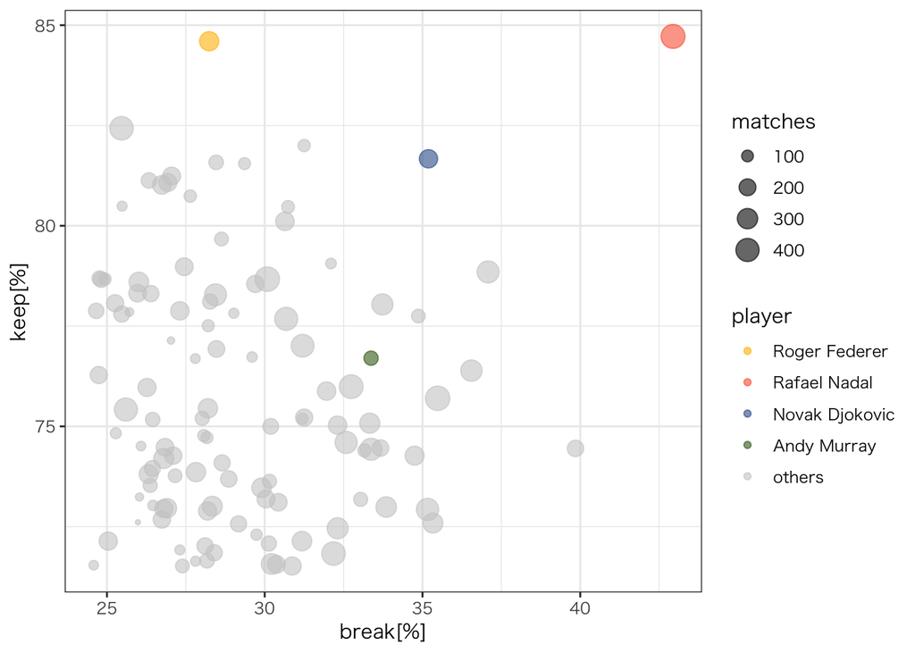

```r
player_list <- c("Roger Federer", "Rafael Nadal", "Novak Djokovic", "Andy Murray" , "others")
color_list <- c("Roger Federer" = "#ffbb00", "Rafael Nadal" = "#fb6542", "Novak Djokovic" = "#375e97", "Andy Murray" = "#3f671c", "others" = "gray80")

df %>%
  dplyr::filter(surface == "Clay") %>%
  na.omit() %>%
  dplyr::mutate(player =  ifelse(player %in% player_list, player, "others")) %>%
  transform(player = factor(player, levels = player_list)) %>%
  ggplot(aes(x=percentage_return, y=percentage_service, color=player, size=matches)) +
  geom_point(alpha = 0.6) +
  scale_color_manual(values = color_list) +
  #scale_color_viridis() +
  xlab("break[%]") +
  ylab("keep[%]")
```

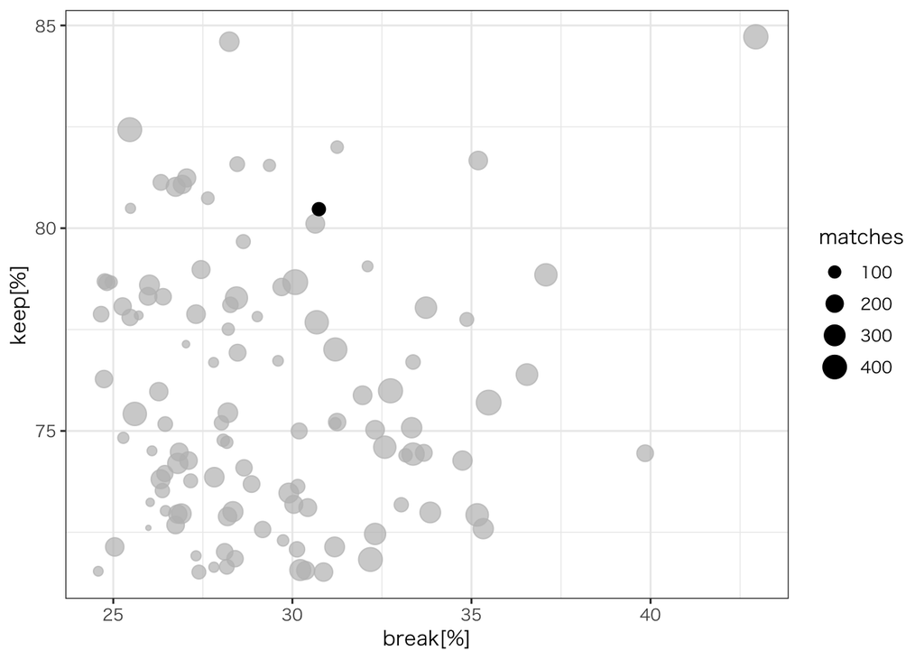

```r
df %>%
  dplyr::filter(surface == "Clay") %>%
  na.omit() %>%
  ggplot(aes(x=percentage_return, y=percentage_service, size=matches)) +
  geom_point() +
  scale_color_viridis() +
  gghighlight(player == "Kei Nishikori") +
  xlab("break[%]") +
  ylab("keep[%]")
```

## keep/break率の分布(surface == “Grass”)

keep/break率のどちらも200位にランクインしている選手で散布図を作成  
(正直、この図に名前が入っているだけですごい選手…)

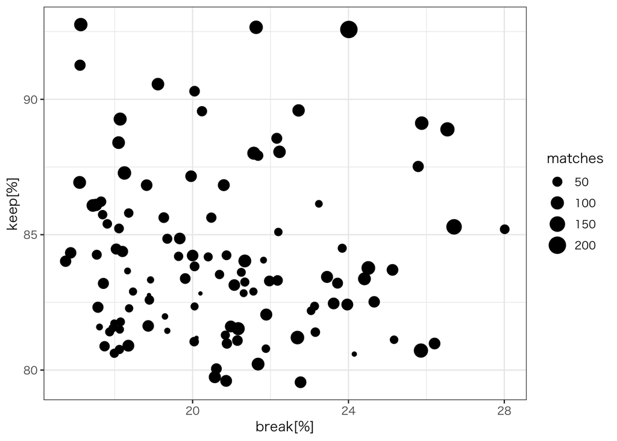

```r
df %>%
  dplyr::filter(surface == "Grass") %>%
  na.omit() %>%
  ggplot(aes(x=percentage_return, y=percentage_service, size=matches)) +
  geom_point() +
  xlab("break[%]") +
  ylab("keep[%]")
```

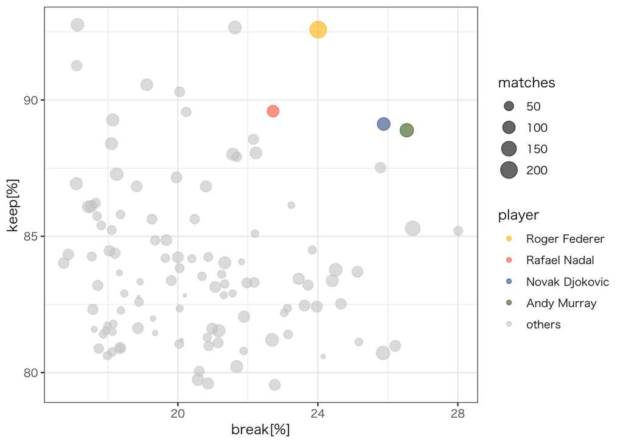

```r
player_list <- c("Roger Federer", "Rafael Nadal", "Novak Djokovic", "Andy Murray" , "others")
color_list <- c("Roger Federer" = "#ffbb00", "Rafael Nadal" = "#fb6542", "Novak Djokovic" = "#375e97", "Andy Murray" = "#3f671c", "others" = "gray80")

df %>%
  dplyr::filter(surface == "Grass") %>%
  na.omit() %>%
  dplyr::mutate(player =  ifelse(player %in% player_list, player, "others")) %>%
  transform(player = factor(player, levels = player_list)) %>%
  ggplot(aes(x=percentage_return, y=percentage_service, color=player, size=matches)) +
  geom_point(alpha = 0.6) +
  scale_color_manual(values = color_list) +
  #scale_color_viridis() +
  xlab("break[%]") +
  ylab("keep[%]")
```

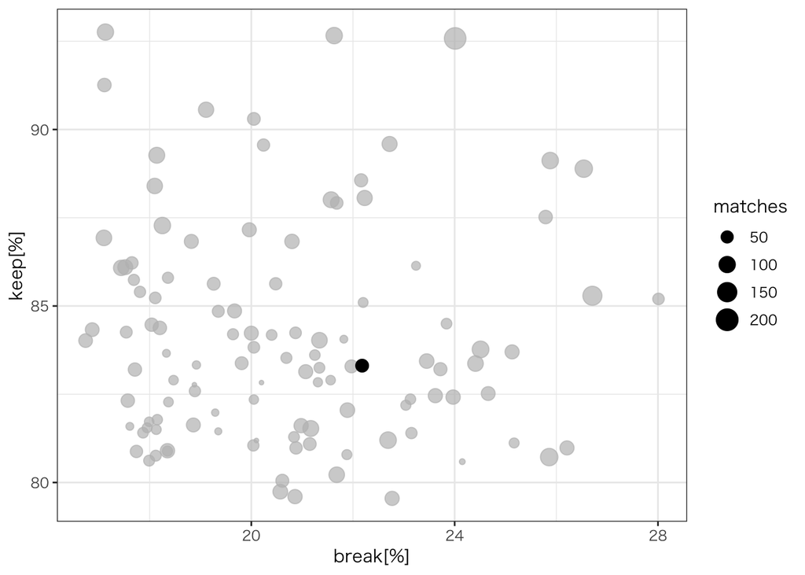

```r
df %>%
  dplyr::filter(surface == "Grass") %>%
  na.omit() %>%
  ggplot(aes(x=percentage_return, y=percentage_service, size=matches)) +
  geom_point() +
  scale_color_viridis() +
  gghighlight(player == "Kei Nishikori") +
  xlab("break[%]") +
  ylab("keep[%]")
```

## keep/break率の分布(surface == “Hard”)

keep/break率のどちらも200位にランクインしている選手で散布図を作成  
(正直、この図に名前が入っているだけですごい選手…)

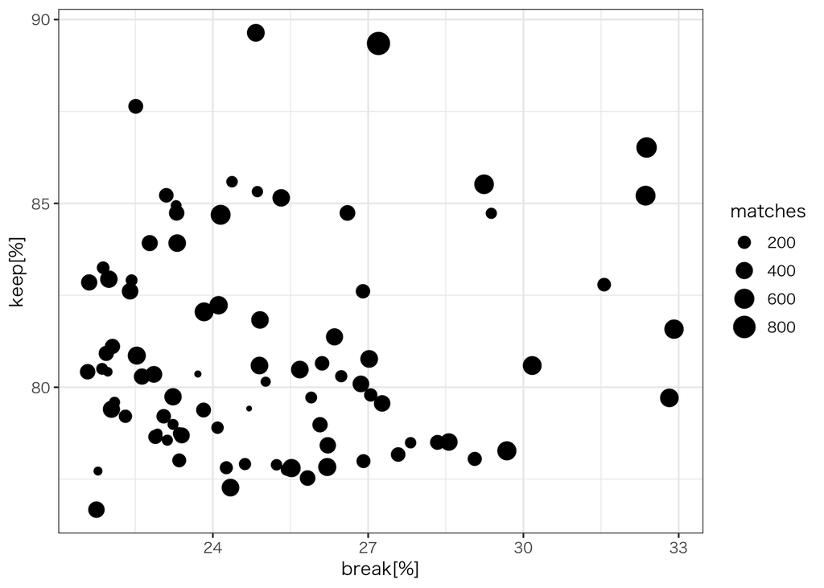

```r
df %>%
  dplyr::filter(surface == "Hard") %>%
  na.omit() %>%
  ggplot(aes(x=percentage_return, y=percentage_service, size=matches)) +
  geom_point() +
  xlab("break[%]") +
  ylab("keep[%]")
```

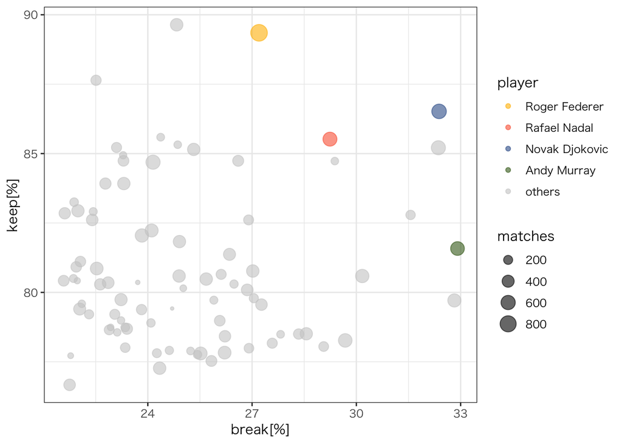

```r
player_list <- c("Roger Federer", "Rafael Nadal", "Novak Djokovic", "Andy Murray" , "others")
color_list <- c("Roger Federer" = "#ffbb00", "Rafael Nadal" = "#fb6542", "Novak Djokovic" = "#375e97", "Andy Murray" = "#3f671c", "others" = "gray80")

df %>%
  dplyr::filter(surface == "Hard") %>%
  na.omit() %>%
  dplyr::mutate(player =  ifelse(player %in% player_list, player, "others")) %>%
  transform(player = factor(player, levels = player_list)) %>%
  ggplot(aes(x=percentage_return, y=percentage_service, color=player, size=matches)) +
  geom_point(alpha = 0.6) +
  scale_color_manual(values = color_list) +
  #scale_color_viridis() +
  xlab("break[%]") +
  ylab("keep[%]")
```

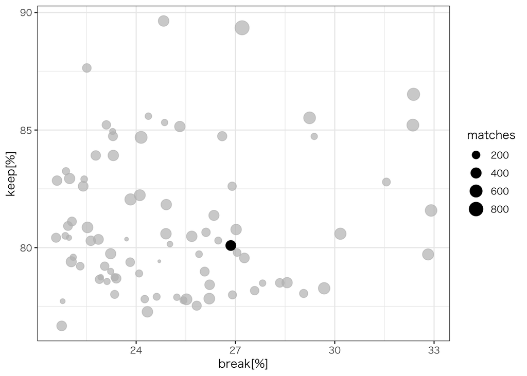

```r
df %>%
  dplyr::filter(surface == "Hard") %>%
  na.omit() %>%
  ggplot(aes(x=percentage_return, y=percentage_service, size=matches)) +
  geom_point() +
  scale_color_viridis() +
  gghighlight(player == "Kei Nishikori") +
  xlab("break[%]") +
  ylab("keep[%]")
```